# Business Economics: Topic 1

## Business Economics: Topic 1

Marcelo Ortiz M.  
Fall

Universitat Pompeu Fabra · Department of Economics and Business

## Topic 1: Human Behavior and Economic Rationality

Objectives:

- Describe the economic model of behavior.
- Apply marginal analysis to managerial decisions.
- Apply the concept of opportunity cost.
- Describe decision-making under uncertainty.
- Contrast the economic model with other behavioral models used by managers.

## Why Do We Need a Model of Economic Behavior?

- We need a framework to understand how people make decisions.
- Managers, employees, suppliers, and customers:
  - They tend to decide in ways that are consistent with their own interests.
- Different framework of decision-making can lead different actions when facing the same challenge.

## Economic Model of Economic Decision-Making

Main ingredients:

- **Unlimited wants**
  - Material items: wealth and assets.
  - Time and leisure activities.
  - Intangibles: reputation, affection, religion, and status.
  - Altruism, help others.
- **Limited resources**
  - Current property or future properties (e.g., borrowing against future income).
  - Time: 24 hours, expected lifetime.

## The Economic Choice

Individuals rank their wants and choose their most preferred option among the alternatives available to them.

- we do not assume people are supercomputers.
  - knowledge is imperfect and information is not always complete.
  - cognitive limits affect how people store, process, and communicate information.
- purposefull action: people choose the alternative that gives them the greatest satisfaction.

## Economic Choice Exercise

For each case, identify:

1. Preferences and alternatives
2. Resources under consideration.
3. Information limits and bounded rationality.
- A customer ordering a meal at McDonald’s.
- A manager deciding which products to include on a menu.

## Economic Choice: McDonald’s

[figure not shown]

[figure not shown]

## Marginal Analysis

- Marginal analysis means making decisions by comparing the additional benefit of **one more unit of an action** with its additional cost.
- Take an action when its incremental benefits exceed its incremental cost.
- Example: you manage a coffee shop:
  - expanding the hour of operation by one hour.
  - expanding staff by one person.
- Implicit costs matter as much as explicit costs.
  - e.g., reputation, team morale, and customer satisfaction.
  - How to price them? if not, how to weigh them against explicit costs and benefits?
- **Sunk costs:** rent paid for the current month.
  - Sunk costs and benefits do not affect a current decision.

## Opportunity Costs

- The opportunity cost is the value of the **best alternative you give up** when you select one action. It is broader than an out-of-pocket payment.
- Shall we keep the cafe open for one more hour?
  - Marginal benefit is the extra revenue the manager expects from that hour: sales of coffee, food, and other items that would not occur if the store closed now.
  - Marginal direct costs: staff salary, electricity, ingredients used in the extra hour.
  - Marginal opportunity cost is the value of the best alternative use of the resources needed for that hour. It can include:
    - money earned by renting the store for private events.
    - money earned by using the same resources in recruiting more employees/ingredients, or marketing campaign.

## Exercise 1

**Car Systems Limited** installs GPS tracking systems on trucks and cars.

- A mining company offers **$20,000** for an installation.
- Labour and other materials cost **$15,000**.
- The GPS devices are in stock. Their historical cost was **$2,000**; their current market price is **$6,000**.

Should the company accept the offer? Identify the wants and alternatives, resources, marginal costs and benefits, and sunk costs and benefits.

## Exercise 2

For each case, identify the resource’s best alternative use, including implicit and explicit costs.

1. An entrepreneur hires a manager to run the current project and moves to the next project.
2. A football player considers an offer from a better-paying league in another country with a different language.
3. A borrower considers not repaying a bank loan.
4. A bakery manager considers dismissing a baker who is losing their sight.

## Culture and Social Psychology in the economic choice problem

- economic choices are made by individuals in a social context: individuals belong to social groups.
- their choices can be influenced by the norms and expectations of those groups.
  - revealed public preferences might differ from real personal preferences.
  - add restrictions to the set of alternatives available to the individual.
- some cultures have stronger social norms than others:
  - e.g., in some cultures, it is socially unacceptable to ask for a raise, to negotiate a price, or to sexually harass a colleague.

## Economic Choice Discussion

Discuss each case in terms of:

1. The decision-maker.
2. Limited resources.
3. Alternative uses.
4. Marginal Benefit
5. Marginal costs, including opportunity costs

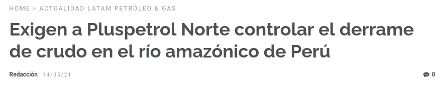

[figure not shown]

## Managerial Implications

- Actions result from people’s economic choices as they seek to maximize personal satisfaction.
- Changing the opportunities people face can change their choices and actions.
- How can managers change employees’ opportunities beyond salary?
- How can managers change customers’ opportunities beyond pricing?

## Preferences and Constraints

Individuals seek the highest level of satisfaction possible given the constraints they face.

- Business economics focuses mainly on the set of alternatives and constraints rather than preferences.
- How can we observe and change people’s preferences?

## Unintended Effects of Incentives: **do not underestimate human creativity**

- Changes in opportunities and incentives affect employee behavior, but not always in the intended way.
  - Example: incentive compensation in the USSR tried to discourage taxi drivers from simply parking their cabs.
- We need to consider all possible responses, for that is important to screen **all feasible alternative decisions** and their consequences.
  - managers (and policymakers) aiming to change individuals behavior should not rush: what is the opportunity cost of a hasty decision?

## Uncertainty

Most managerial decisions involve alternatives with uncertain outcomes.

Case: R&D investment.

[figure not shown]

Other cases:

- Hiring new employees.
- Adopting new production technologies.

For each case, identify the decision, its possible outcomes, and the associated risks.

We need additional tools to handle uncertainty in these decisions.

$$E[\text{payoff}] = \sum_i \left(\text{payoff}_i \times \Pr(\text{state}_i)\right)$$

$$V[\text{payoff}] = E[\text{payoff}^2] - E[\text{payoff}]^2$$

- A risk-averse person prefers a lower standard deviation of payoffs when expected payoff remains fixed.
- A risk-neutral person cares only about expected value and is indifferent to the amount of risk.
- **Certainty equivalent:** a fixed payment that gives the same satisfaction as a risky option.
- **Risk premium:** the additional expected payment needed to keep someone indifferent between a risky and a certain option.

Example: if a person is indifferent between a fixed salary of **$80,000** and a commission scheme with expected value **$100,000**, the certainty equivalent is $80,000 and the risk premium is $20,000.

## Risk Aversion and Compensation

- How diversified is the wealth of shareholders?
- How diversified is the wealth of a CEO?
- Who has more reason to be risk-averse?
- Does this create a conflict of objectives? How could it be addressed?

## Alternative Models of Behavior

- Some managerial decisions require attention to individual characteristics: selecting the new CEO for the firm’s next stage of development.
  - Psychological attributes, past experiences, and social capital or networks differ across candidates.
- Psychology and sociology can complement, or sometimes improve, the analysis of behavior.

## Summary

Main concepts:

- Economic choice problem.
- Preferences and bounded rationality.
- Marginal analysis.
- Opportunity cost.
- Risk aversion.

**Questions?**

Check my website for an updated version of this presentation:

https://www.marceloortizm.com/